# Pipes and Least Squares Estimation

Fundamental Techniques in Data Science with R

## Today

## This lecture

- Data manipulation
- Basic analysis (correlation & t-test)
- Pipes
- Deviations and modeling

## New Packages

```r
library(MASS)     # The cats data
library(dplyr)    # Data manipulation
library(haven)    # Data I/O
library(magrittr) # Pipes
library(mice)     # The nhanes data
```

[figure not shown]

## New Functions

- `transform()`: changing and adding columns
- `dplyr::filter()`: row-wise selection (of cases)
- `table()`: frequency tables
- `class()`: object class
- `levels()`: levels of a factor
- `order()`: data entries in increasing order
- `haven::read_sav()`: import SPSS data
- `cor()`: bivariate correlation
- `sample()`: sampling values from a vector
- `t.test()`: t-test

## Data manipulation

## The cats data

```r
head(cats)
```

```
##   Sex Bwt Hwt
## 1   F 2.0 7.0
## 2   F 2.0 7.4
## 3   F 2.0 9.5
## 4   F 2.1 7.2
## 5   F 2.1 7.3
## 6   F 2.1 7.6
```

```r
str(cats)
```

```
## 'data.frame':    144 obs. of  3 variables:
##  $ Sex: Factor w/ 2 levels "F","M": 1 1 1 1 1 1 1 1 1 1 ...
##  $ Bwt: num  2 2 2 2.1 2.1 2.1 2.1 2.1 2.1 2.1 ...
##  $ Hwt: num  7 7.4 9.5 7.2 7.3 7.6 8.1 8.2 8.3 8.5 ...
```

## How to get only female cats?

```r
femCats <- cats[cats$Sex == "F", ]
dim(femCats)
```

```
## [1] 47  3
```

```r
head(femCats)
```

```
##   Sex Bwt Hwt
## 1   F 2.0 7.0
## 2   F 2.0 7.4
## 3   F 2.0 9.5
## 4   F 2.1 7.2
## 5   F 2.1 7.3
## 6   F 2.1 7.6
```

## How to get only “heavy” cats?

```r
heavyCats <- cats[cats$Bwt > 3, ]
dim(heavyCats)
```

```
## [1] 36  3
```

```r
head(heavyCats)
```

```
##     Sex Bwt  Hwt
## 109   M 3.1  9.9
## 110   M 3.1 11.5
## 111   M 3.1 12.1
## 112   M 3.1 12.5
## 113   M 3.1 13.0
## 114   M 3.1 14.3
```

## How to get only “heavy” cats?

```r
heavyCats <- subset(cats, Bwt > 3)
dim(heavyCats)
```

```
## [1] 36  3
```

```r
head(heavyCats)
```

```
##     Sex Bwt  Hwt
## 109   M 3.1  9.9
## 110   M 3.1 11.5
## 111   M 3.1 12.1
## 112   M 3.1 12.5
## 113   M 3.1 13.0
## 114   M 3.1 14.3
```

## How to get only “heavy” cats?

We can also use the `filter()` function provided by **dplyer**.

```r
filter(cats, Bwt > 2, Bwt < 2.2, Sex == "F")
```

```
##   Sex Bwt Hwt
## 1   F 2.1 7.2
## 2   F 2.1 7.3
## 3   F 2.1 7.6
## 4   F 2.1 8.1
## 5   F 2.1 8.2
## 6   F 2.1 8.3
## 7   F 2.1 8.5
## 8   F 2.1 8.7
## 9   F 2.1 9.8
```

## Working with Factors

```r
class(cats$Sex)
```

```
## [1] "factor"
```

```r
levels(cats$Sex)
```

```
## [1] "F" "M"
```

## Working with Factors

```r
levels(cats$Sex) <- c("Female", "Male")
table(cats$Sex)
```

```
##
## Female   Male
##     47     97
```

```r
head(cats)
```

```
##      Sex Bwt Hwt
## 1 Female 2.0 7.0
## 2 Female 2.0 7.4
## 3 Female 2.0 9.5
## 4 Female 2.1 7.2
## 5 Female 2.1 7.3
## 6 Female 2.1 7.6
```

## Sorting

```r
sortedCats <- cats[order(cats$Bwt), ]
head(sortedCats)
```

```
##       Sex Bwt Hwt
## 1  Female 2.0 7.0
## 2  Female 2.0 7.4
## 3  Female 2.0 9.5
## 48   Male 2.0 6.5
## 49   Male 2.0 6.5
## 4  Female 2.1 7.2
```

## Combining Matrices or Data Frames

```r
catsNumeric <- cbind(weight = cats$Bwt, heartWeight = cats$Hwt)
head(catsNumeric)
```

```
##      weight heartWeight
## [1,]    2.0         7.0
## [2,]    2.0         7.4
## [3,]    2.0         9.5
## [4,]    2.1         7.2
## [5,]    2.1         7.3
## [6,]    2.1         7.6
```

## Combining Matrices or Data Frames

```r
rbind(cats[1:3, ], cats[1:5, ])
```

```
##      Sex Bwt Hwt
## 1 Female 2.0 7.0
## 2 Female 2.0 7.4
## 3 Female 2.0 9.5
## 4 Female 2.0 7.0
## 5 Female 2.0 7.4
## 6 Female 2.0 9.5
## 7 Female 2.1 7.2
## 8 Female 2.1 7.3
```

## Basic analysis

## Correlation

```r
cor(cats[, -1])
```

```
##           Bwt       Hwt
## Bwt 1.0000000 0.8041274
## Hwt 0.8041274 1.0000000
```

The `[, -1]` part excludes the first column.

## Correlation

Test the null hypothesis that the true correlation is equal to zero.

```r
cor.test(cats$Bwt, cats$Hwt)
```

```
##
##  Pearson's product-moment correlation
##
## data:  cats$Bwt and cats$Hwt
## t = 16.119, df = 142, p-value < 2.2e-16
## alternative hypothesis: true correlation is not equal to 0
## 95 percent confidence interval:
##  0.7375682 0.8552122
## sample estimates:
##       cor
## 0.8041274
```

What should we conclude?

## Correlation

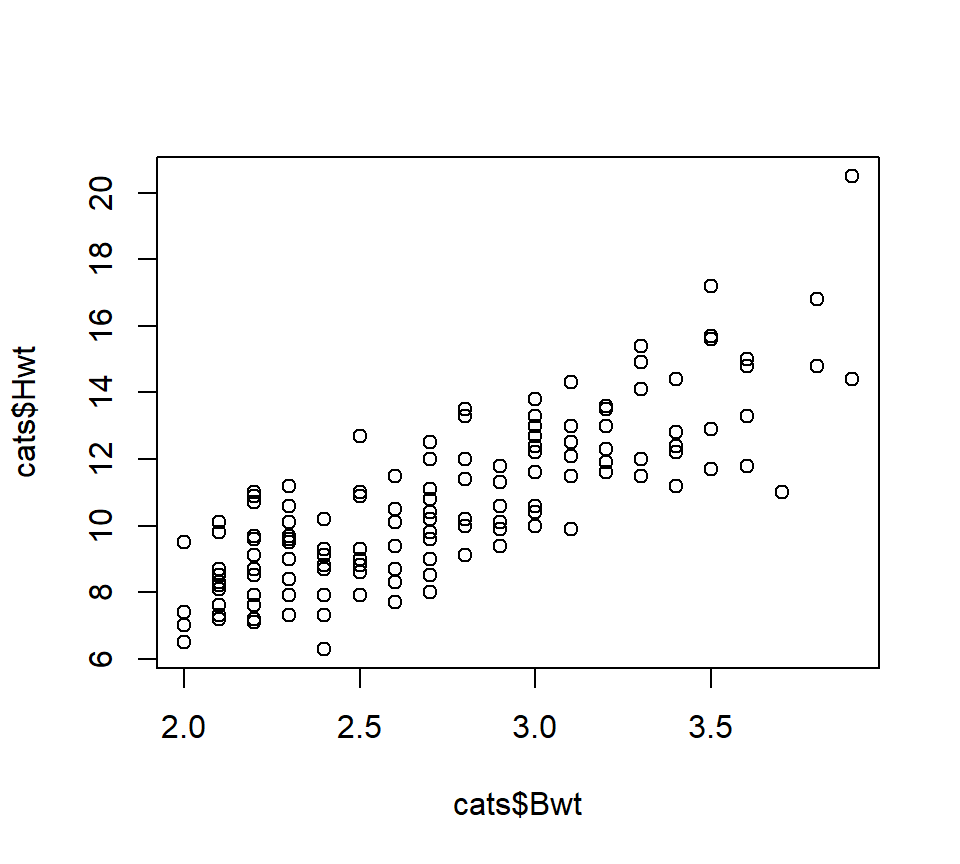

```r
plot(cats$Bwt, cats$Hwt)
```

## T-test

Test the null hypothesis that the mean heart weight for male cats is equal to the mean heart weight for female cats.

```r
t.test(formula = Hwt ~ Sex, data = cats)
```

```
##
##  Welch Two Sample t-test
##
## data:  Hwt by Sex
## t = -6.5179, df = 140.61, p-value = 1.186e-09
## alternative hypothesis: true difference in means between group Female and group Male is not equal to 0
## 95 percent confidence interval:
##  -2.763753 -1.477352
## sample estimates:
## mean in group Female   mean in group Male
##             9.202128            11.322680
```

## T-test

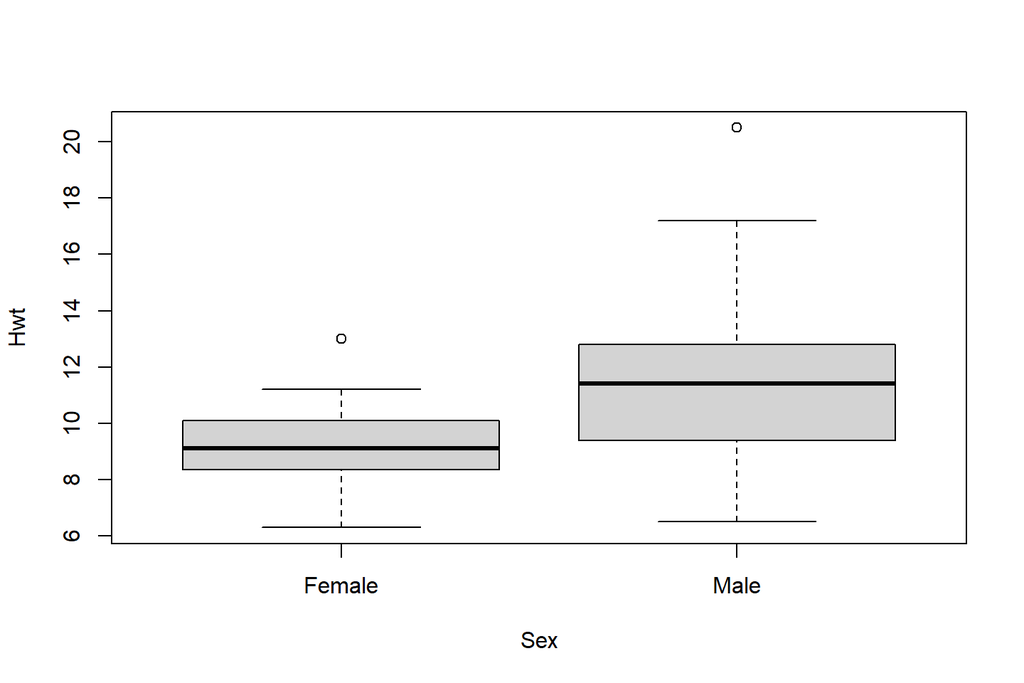

```r
plot(formula = Hwt ~ Sex, data = cats)
```

## Pipes

## What are pipes?

The `%>%` symbol represents the *pipe* operator.

- We use the pipe operator to compose functions into a *pipeline*.

The following code represents a pipeline.

```r
firstBoys <-
  read_sav("data/boys.sav") %>%
  head()
```

This pipeline replaces the following code.

```r
firstBoys <- head(read_sav("data/boys.sav"))
```

## Why are pipes useful?

Let’s assume that we want to:

1. Load data
2. Transform a variable
3. Filter cases
4. Select columns

Without a pipe, we may do something like this:

```r
boys <- read_sav("data/boys.sav")
boys <- transform(boys, hgt = hgt / 100)
boys <- filter(boys, age > 15)
boys <- subset(boys, select = c(hgt, wgt, bmi))
```

## Why are pipes useful?

Let’s assume that we want to:

1. Load data
2. Transform a variable
3. Filter cases
4. Select columns

With the pipe, we could do something like this:

```r
boys <-
  read_sav("data/boys.sav") %>%
  transform(hgt = hgt / 100) %>%
  filter(age > 15) %>%
  subset(select = c(hgt, wgt, bmi))
```

With a pipeline, our code more clearly represents the sequence of steps in our analysis.

## Benefits of Pipes

When you use pipes, your code becomes more readable.

- Operations are structured from left-to-right and not from in-to-out
- You can avoid many nested function calls
- You don’t have to keep track of intermediate objects
- It’s easy to add steps to the sequence

In RStudio, you can use a keyboard shortcut to insert the `%>%` symbol.

- Windows/Linux: *ctrl* + *shift* + *m*
- Mac: *cmd* + *shift* + *m*

## What do pipes do?

Pipes compose R functions without nesting.

- `f(x)` becomes `x %>% f()`

```r
mean(rnorm(10))
```

```
## [1] -0.03294782
```

```r
rnorm(10) %>% mean()
```

```
## [1] -0.06662666
```

## What do pipes do?

Multiple function arguments are fine.

- `f(x, y)` becomes `x %>% f(y)`

```r
cor(boys, use = "pairwise.complete.obs")
```

```
##           hgt       wgt       bmi
## hgt 1.0000000 0.6100784 0.1758781
## wgt 0.6100784 1.0000000 0.8841304
## bmi 0.1758781 0.8841304 1.0000000
```

```r
boys %>% cor(use = "pairwise.complete.obs")
```

```
##           hgt       wgt       bmi
## hgt 1.0000000 0.6100784 0.1758781
## wgt 0.6100784 1.0000000 0.8841304
## bmi 0.1758781 0.8841304 1.0000000
```

## What do pipes do?

Composing more than two functions is easy, too.

- `h(g(f(x)))` becomes `x %>% f %>% g %>% h`

```r
max(na.omit(subset(boys, select = wgt)))
```

```
## [1] 117.4
```

```r
boys %>%
  subset(select = wgt) %>%
  na.omit() %>%
  max()
```

```
## [1] 117.4
```

## Example: Outlier Filtering

```r
nrow(cats)
```

```
## [1] 144
```

```r
cats2 <-
  cats %>%
  filter(Hwt < mean(Hwt) + 3 * sd(Hwt),
         Hwt > mean(Hwt) - 3 * sd(Hwt)
         )

nrow(cats2)
```

```
## [1] 143
```

```r
cats %>% filter(Hwt > mean(Hwt) + 3 * sd(Hwt))
```

```
##    Sex Bwt  Hwt
## 1 Male 3.9 20.5
```

## More Pipe Stuff

## The Role of `.` in a Pipeline

In the expression `a %>% f(arg1, arg2, arg3)`, `a` will be “piped into” `f()` as `arg1`.

```r
cats %>% plot(Hwt ~ Bwt)
```

```
## Error in text.default(x, y, txt, cex = cex, font = font): invalid mathematical annotation
```

Clearly, we have a problem if we pipe our data into the wrong argument.

- We can change this behavior with the `.` symbol.
- The `.` symbol acts as a placeholder for the data in a pipeline.

## The Role of `.` in a Pipeline

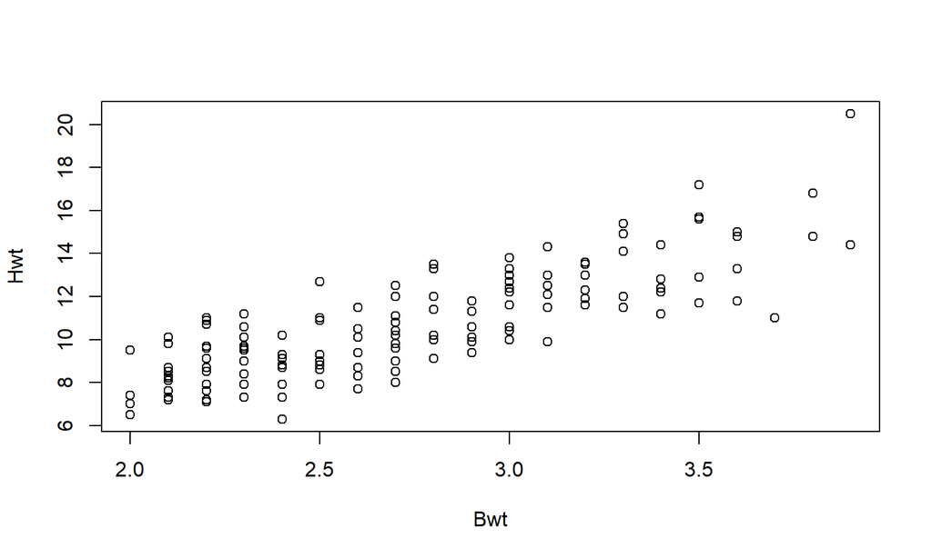

```r
cats %>% plot(Hwt ~ Bwt, data = .)
```

## Different Flavors of Pipe

The standard pipe (`%>%`)

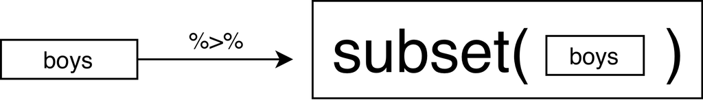

The exposition pipe (`%$%`)

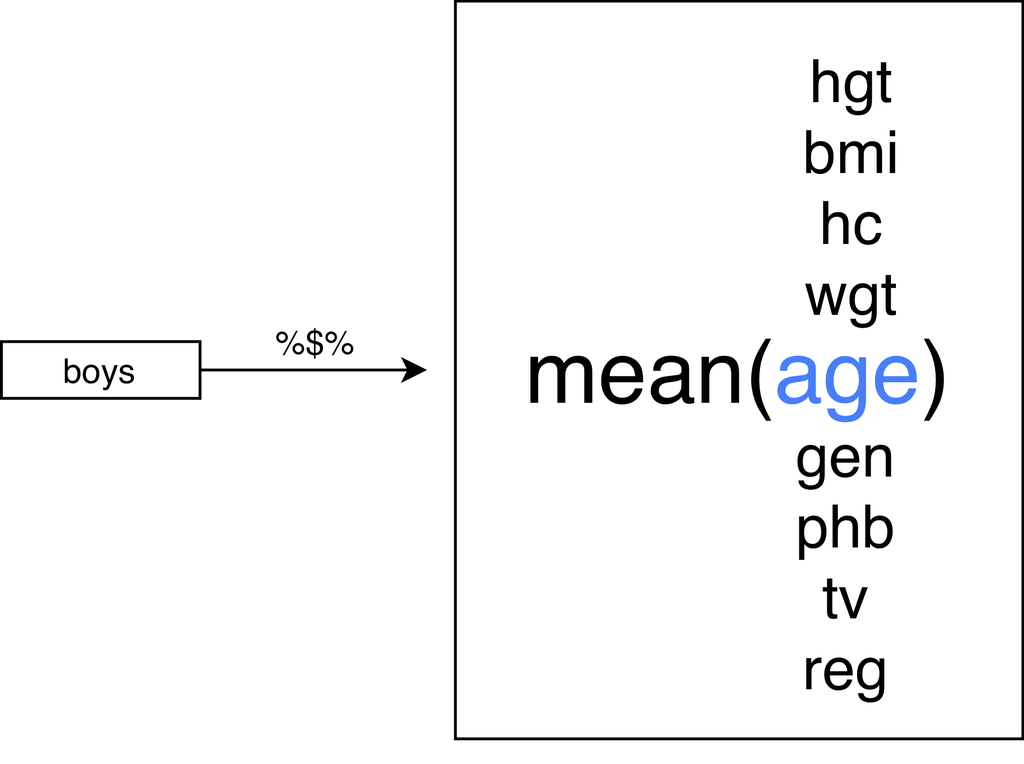

## Using the Exposition Pipe: `%$%`

The exposition pipe offers a more elegant way to solve our earlier problem.

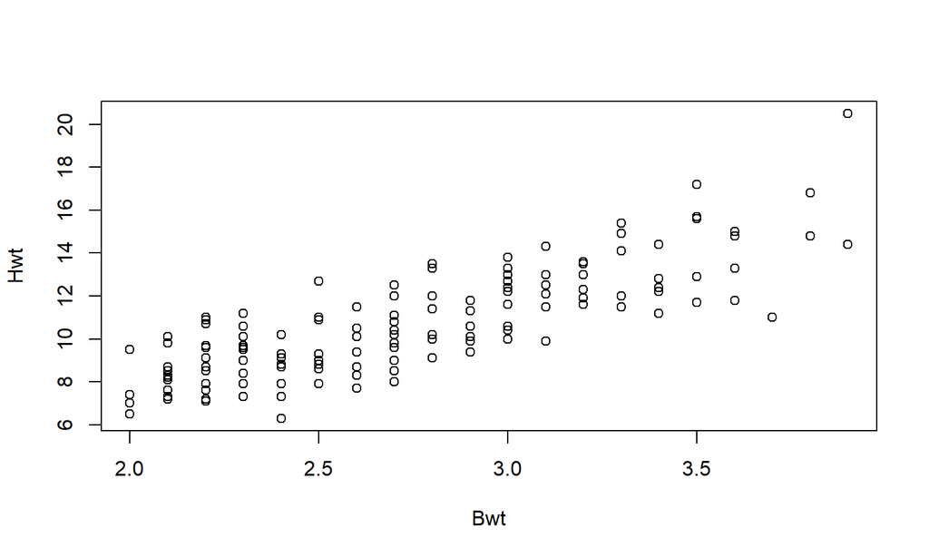

```r
cats %$% plot(Hwt ~ Bwt)
```

## Performing a T-Test in a Pipeline

```r
cats %$% t.test(Hwt ~ Sex)
```

```
##
##  Welch Two Sample t-test
##
## data:  Hwt by Sex
## t = -6.5179, df = 140.61, p-value = 1.186e-09
## alternative hypothesis: true difference in means between group Female and group Male is not equal to 0
## 95 percent confidence interval:
##  -2.763753 -1.477352
## sample estimates:
## mean in group Female   mean in group Male
##             9.202128            11.322680
```

The above is equivalent to either of the following.

```r
cats %>% t.test(Hwt ~ Sex, data = .)
t.test(Hwt ~ Sex, data = cats)
```

## Storing the Results

```r
catsTest <- cats %$% t.test(Bwt ~ Sex)

catsTest
```

```
##
##  Welch Two Sample t-test
##
## data:  Bwt by Sex
## t = -8.7095, df = 136.84, p-value = 8.831e-15
## alternative hypothesis: true difference in means between group Female and group Male is not equal to 0
## 95 percent confidence interval:
##  -0.6631268 -0.4177242
## sample estimates:
## mean in group Female   mean in group Male
##             2.359574             2.900000
```

## Squared Deviations

## Applications of Deviations

Correlations

\[\rho_{X,Y} = \frac{\mathrm{cov}(X,Y)}{\sigma_X\sigma_Y} = \frac{\mathrm{E}[(X - \mu_X)(Y-\mu_Y)]}{\sigma_X\sigma_Y}\]

T-Test

\[t = \frac{\bar{X}-\mu}{\hat{\sigma}/\sqrt{n}}\] Variance

\[\sigma^2_X = \mathrm{E}[(X - \mu)^2]\]

## Deviations

Deviations are simply the differences between each of a variable’s values and some comparison value.

- Deviations quantify the distance between a variable’s values and the comparison point.
- The mean is frequently chosen as the comparison value.

The mean itself can be viewed as a simple statistical model.

- In some sense, the mean represents our best guess for the value of any of a variable’s observations.

## Example Data

Let’s consider some bivariate normal data.

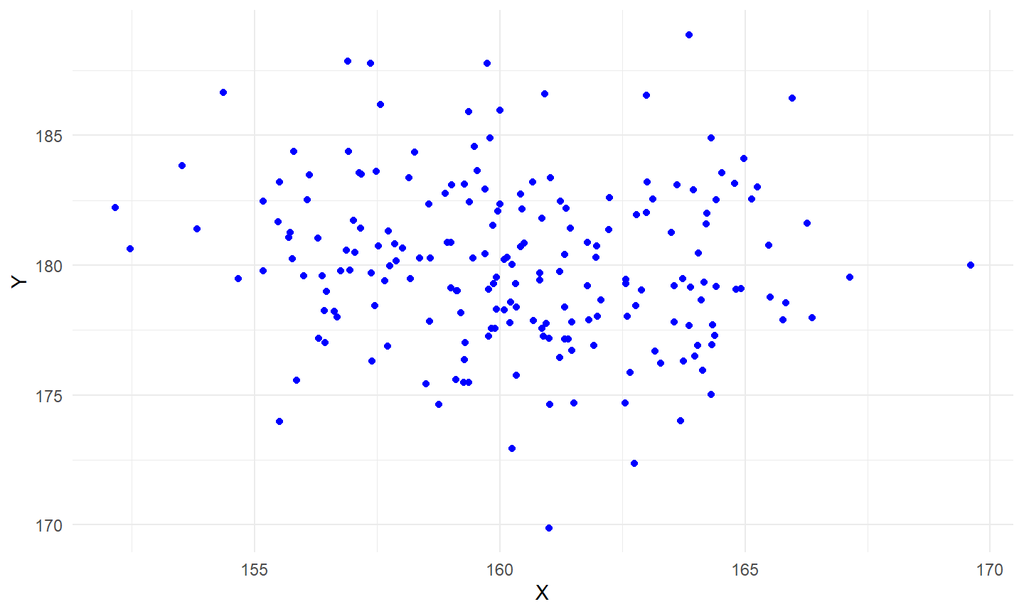

## The Mean as Center of Mass

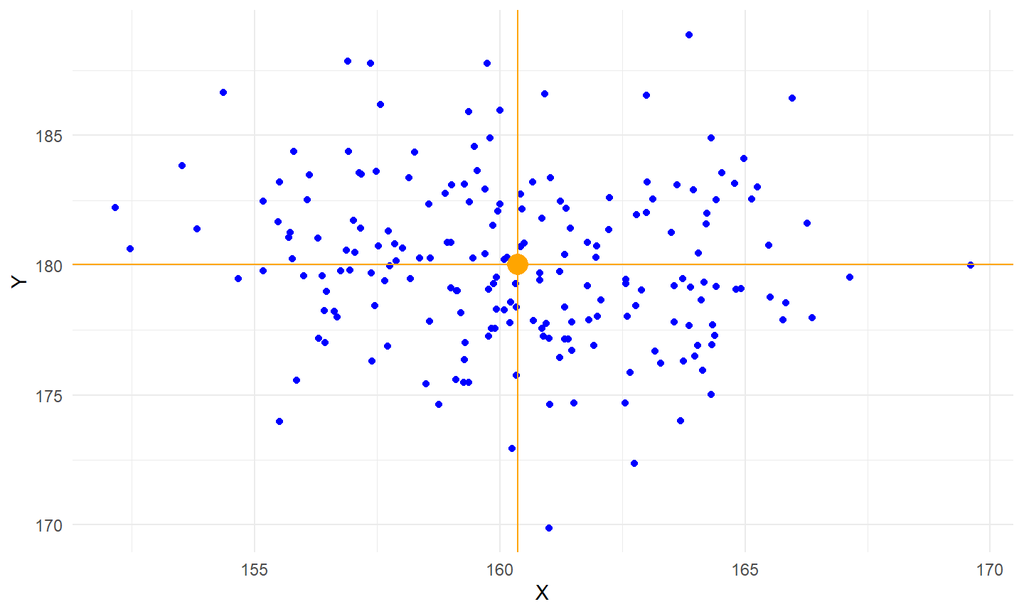

## Deviations from the Mean of X

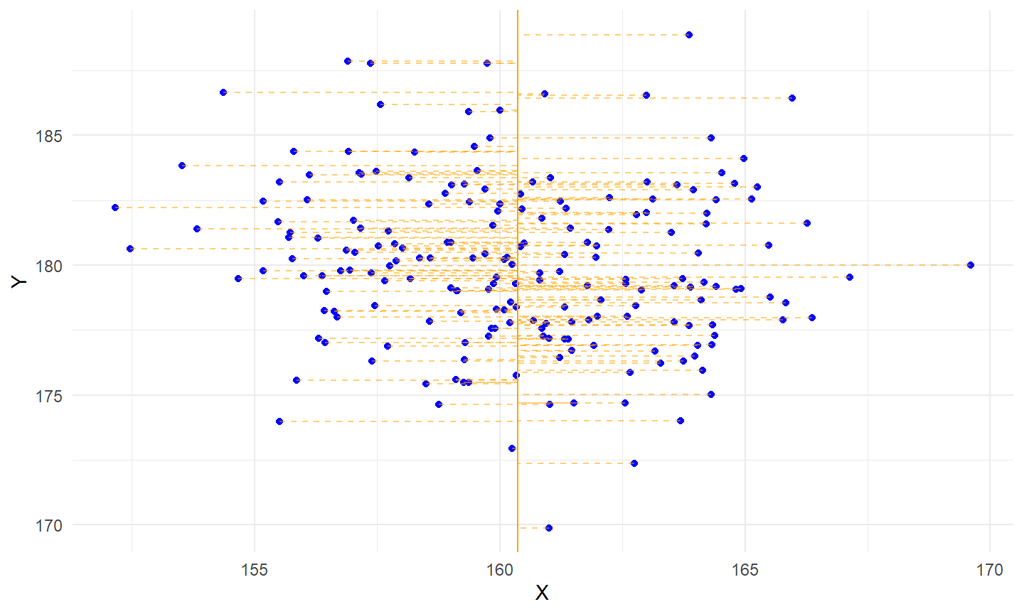

## Distribution of Deviations

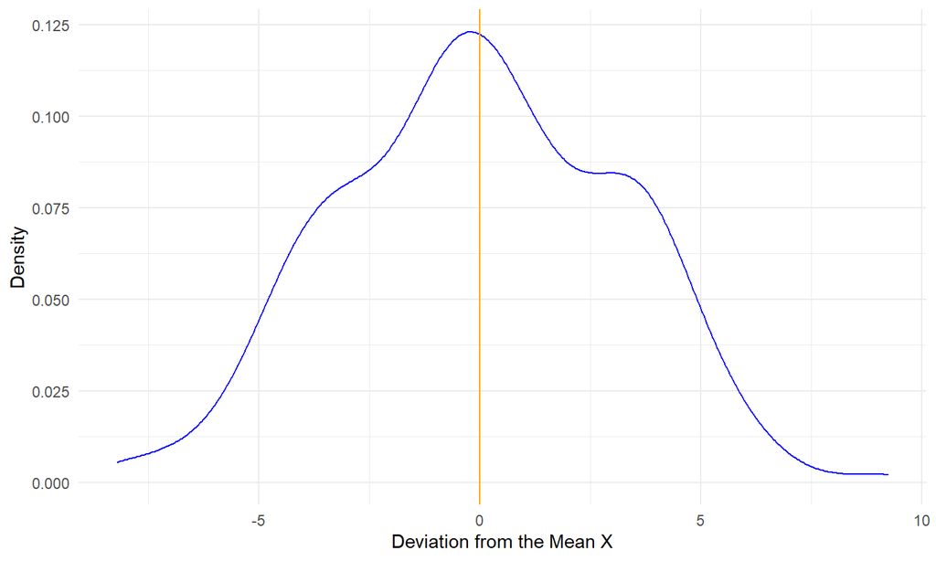

## Using Deviations

The sum of the deviations summarizes the fit of the comparison point to the individual data points.

- If the comparison point is a “good” single-value representation of the data, the sum of the deviations should be zero.

The mean satisfies this desiderata.

```r
## Deviations about the mean:
with(dat1, sum(X - mean(X)))
```

```
## [1] 2.756906e-12
```

```r
## Deviations about the mean + 3:
with(dat1, sum(X - (mean(X) + 3)))
```

```
## [1] -600
```

## Visualize the Difference

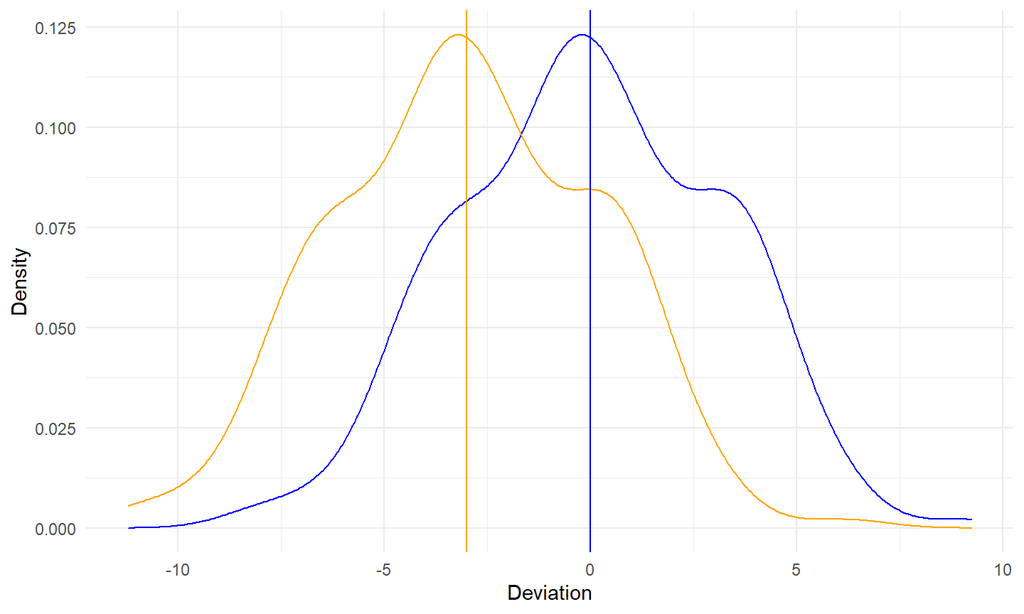

## Distribution of Standardized Deviations

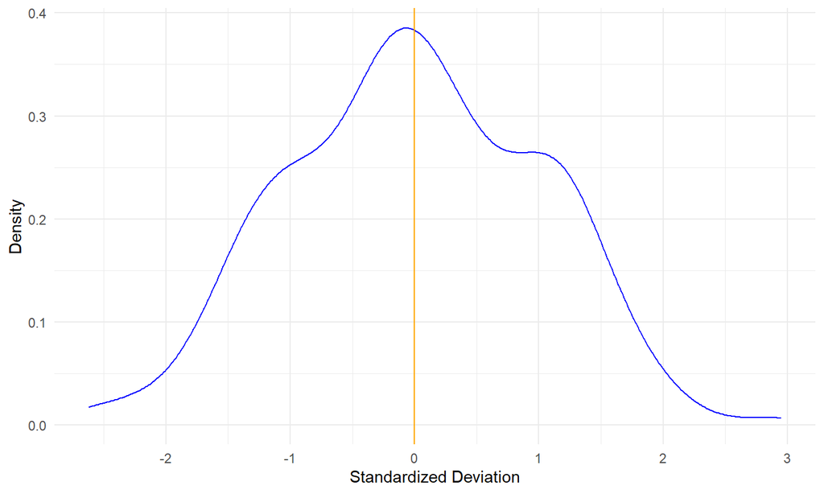

## Distribution of Squared Deviations

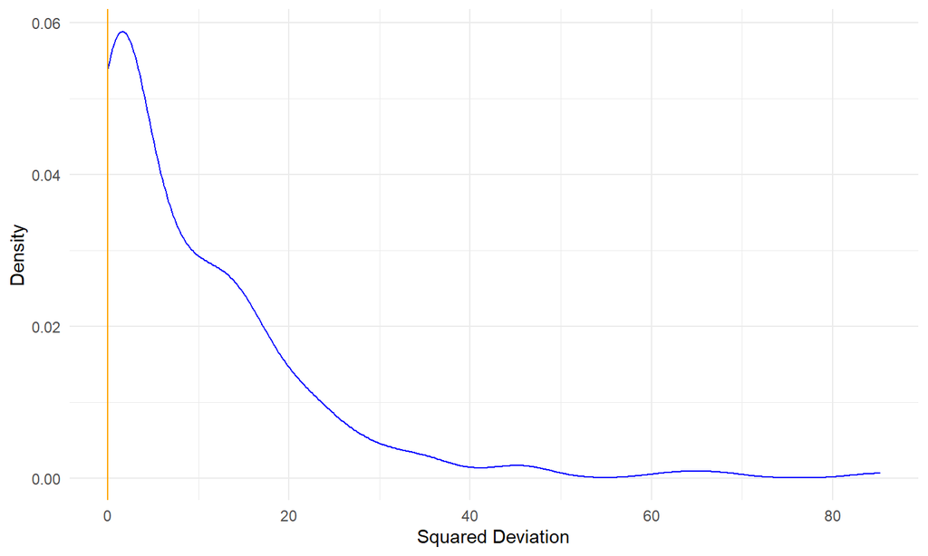

## The Effects of Squaring

Statisticians make extensive use of squaring. What are the consequences?

- The sum of squared values is always positive.
  - Helps with floating-point underflow problems
- Squaring linear functions converts them to quadratic functions.
  - Better for optimization
- Squaring has a disproportionate effect on larger values.
  - Outliers are a problem.

## Deviations from the Mean of Y

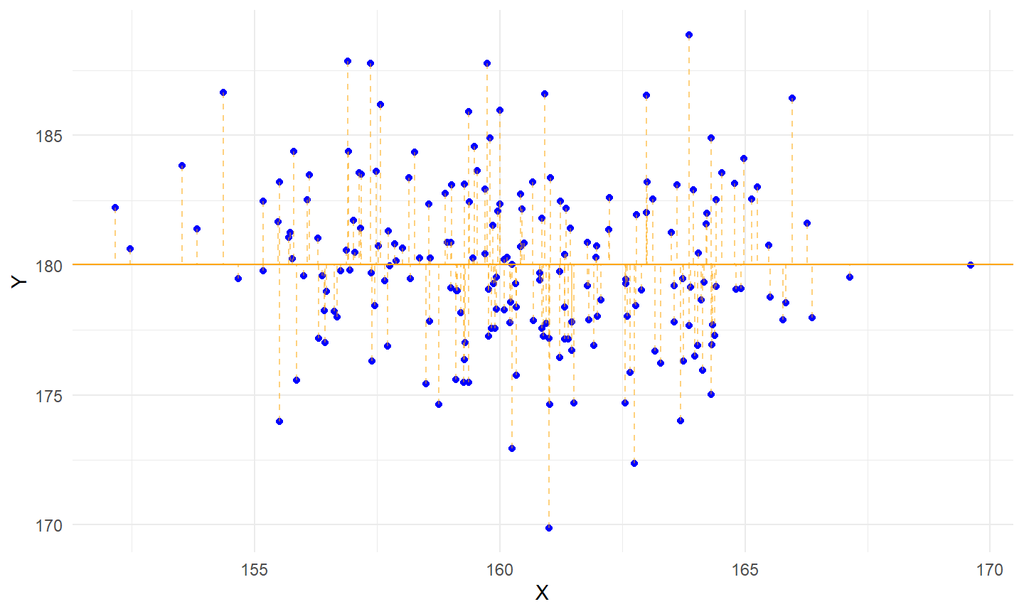

## Deviations from the Bivariate Mean

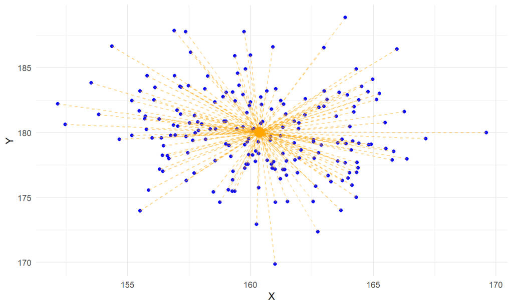

## Least Squares Solution

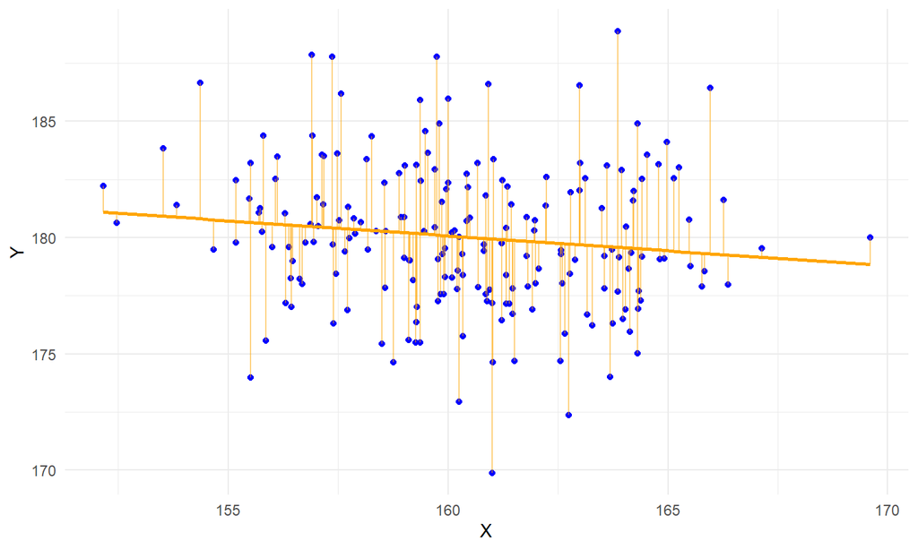

## Data with a Stronger Effect

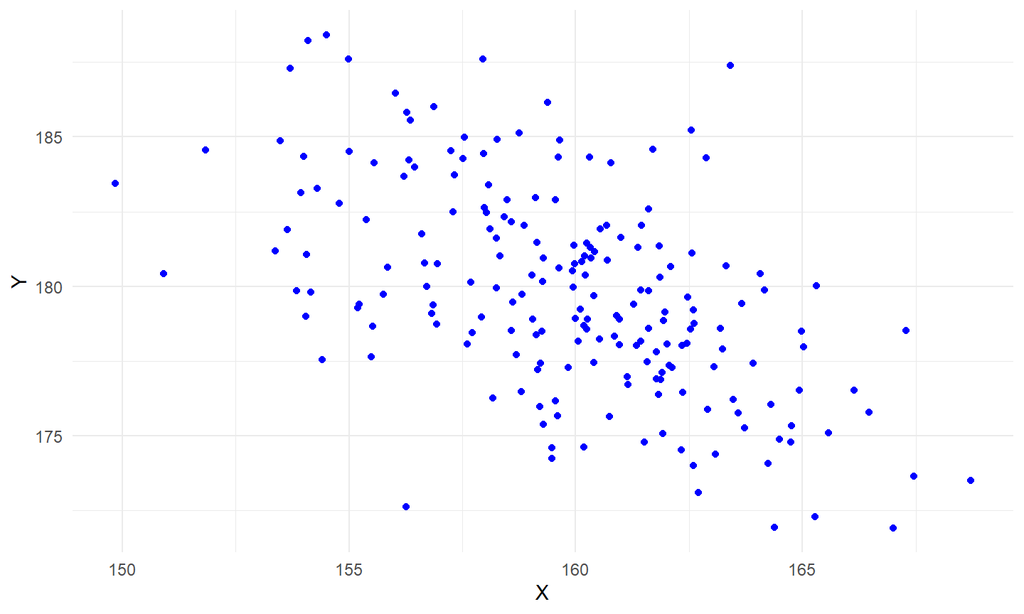

## Least Squares Solution

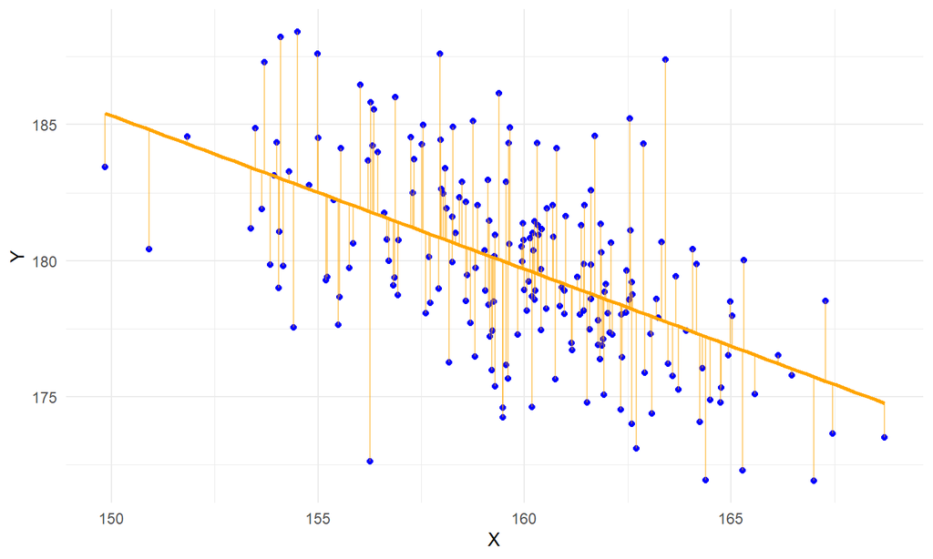